# Summary for final report

Jackie Ouzman

08/09/2021

## Number of N and P trials for 2020 -2021 season

CSIRO team have been supplied with spatial data for the location of strip trials. Along with this information we have details on the type of trial (either N or P) and the fertilisers used.

Note that a few paddocks have both N and P trials.

Most paddocks have two zone, but some have just one and some have multiple zone. This is filtering data out that is marked excluded from analysis and ensured I am only keeping unique Zone ID.

2020 season. Zone per fertilsier strip type (using zone shapefile).

```
## # A tibble: 3 x 2
##   Strip_Type       count_zones_by_type
## * <fct>                          <int>
## 1 N Strip                           71
## 2 N Strip, P Strip                   2
## 3 P Strip                          103
```

2020 season.Paddocks per fertilsier strip type.

```
## # A tibble: 3 x 2
##   Strip_Type       count_paddocks_by_type
## * <fct>                             <int>
## 1 N Strip                              33
## 2 N Strip, P Strip                      1
## 3 P Strip                              52
```

2020 season. How many growers?

```
##   count_farmers_by_type
## 1                    62
```

I can run the same analysis with the strip files but the numbers are slightly different because of the trials that have N and P. So I will use the zone shapefile as a basis. The code is here but I am not displaying the output.

## Number of N and P trials for 2019 -2020 season

2019 season. Zone per fertilsier strip type (using zone shapefile).

```
## # A tibble: 3 x 2
##   Strip_Type count_zones_by_type
## * <fct>                    <int>
## 1 N Strip                     33
## 2 P Strip                     80
## 3 P&N Strip                    6
```

2019 season.Paddocks per fertilsier strip type.

```
## # A tibble: 3 x 2
##   Strip_Type count_paddocks_by_type
## * <fct>                       <int>
## 1 N Strip                        15
## 2 P Strip                        37
## 3 P&N Strip                       4
```

2019 season. How many growers?

```
## # A tibble: 3 x 2
##   Strip_Type count_farmers_by_type
## * <fct>                      <int>
## 1 N Strip                       10
## 2 P Strip                       21
## 3 P&N Strip                      3
```

```
##   count_farmers
## 1            34
```

## How do the recommended rates 2020 -2021 season compare in the multiple zones in the paddock

I have used the low, medium, high rainfall class generated by the location of the trial.

Rather than using the database, which has some odd rainfall classifications. Note Sean has not used the rainfall classification in the DB to generate his N recommendation. Sean has used a different rainfall class and his N recommendation (that he has used for analysis and presentations sit outside of the database) I have redone the N recommendation based on the revised rainfall class. This revised rainfall class is based on the spatial location of the paddocks. Using this with BOM average rainfall grid and low med and high class defined by Therese.

Sean is still getting back to me regarding how to calculate the P recommendation. Looks like there might be an issue with the P recommendation, I have re calculated them.

I am still waiting for confirmation from Sean.

For P trials in 2020 The number of paddocks with either 1, 2,3 zones How many paddocks have a P rec rate in zone 1 vs zone 2 that is higher than 5 kg

```
## # A tibble: 3 x 2
##   count_zone sum_of_when_diff
## *      <int>            <dbl>
## 1          1                0
## 2          2               24
## 3          3                0
```

```
## # A tibble: 1 x 3
##   sum_of_when_diff count percent_zone_with_diff_rec_P
##              <dbl> <int>                        <dbl>
## 1               24    53                         45.3
```

For N trials in 2020 The number of paddocks with either 1, 2,3 zones How many paddocks have a P rec rate in zone 1 vs zone 2 that is higher than 10 kg

Note for the paddocks with the one than 2 zone I have just reported on the max difference. For example what was the min and max recommedation.

```
## # A tibble: 4 x 2
##   count_zone sum_of_when_diff
## *      <int>            <dbl>
## 1          1                0
## 2          2               19
## 3          3                3
## 4          4                2
```

```
## # A tibble: 1 x 3
##   sum_of_when_diff count percent_zone_with_diff_rec_N
##              <dbl> <int>                        <dbl>
## 1               24    34                         70.6
```

## How do the recommended rates 2019 -2020 season compare in the multiple zones in the paddock

I have now used updated calculation. I am still waiting on Sean to confirm that my P recommendation calculation is correct.

```
## # A tibble: 4 x 2
##   count_zone sum_of_when_diff
## *      <int>            <dbl>
## 1          1                0
## 2          2               10
## 3          3                1
## 4          6                1
```

```
## # A tibble: 1 x 3
##   sum_of_when_diff count percent_zone_with_diff_rec_P
##              <dbl> <int>                        <dbl>
## 1               12    36                         33.3
```

```
## # A tibble: 4 x 2
##   count_zone sum_of_when_diff
## *      <int>            <dbl>
## 1          1                0
## 2          2                5
## 3          3                1
## 4          4                1
```

```
## # A tibble: 1 x 3
##   sum_of_when_diff count percent_zone_with_diff_rec_N
##              <dbl> <int>                        <dbl>
## 1                7    15                         46.7
```

## Details on the soil test, recommend rates and the average GSP

### 2019 data

This data set is not great. I have patchy records for the fertiliser applied and how much was applied over the season.

Therese has done a lot of work here but some sites just don’t seem to add up. A variety of problems, I have used her work as a cross reference.

I have done the N rec rates again and P rec rates - waiting for Sean to confirm rates cals are correct

```
## # A tibble: 3 x 6
##   rainfall_class Av_P_Colwell Av_P_DGT Av_P_PBI Av_P_rec_rate Av_P_GSP
## * <fct>                 <dbl>    <dbl>    <dbl>         <dbl>    <dbl>
## 1 low                    20.2     49.6     68.3         12.4      9.29
## 2 medium                 74.4     86.9     78.9          7.41    11.6
## 3 high                   52.7     72.2     76.7          9.17     9.63
```

```
## # A tibble: 3 x 4
##   rainfall_class Av_N_Total_N Av_N_rec_rate Av_N_GSP
## * <fct>                 <dbl>         <dbl>    <dbl>
## 1 low                    118.            0      23.5
## 2 medium                 120.          103.     44.9
## 3 high                   355.            0      51.2
```

### 2020 data

```
## # A tibble: 3 x 6
##   rainfall_class Av_P_Colwell Av_P_DGT Av_P_PBI Av_P_rec_rate Av_P_GSP
## * <fct>                 <dbl>    <dbl>    <dbl>         <dbl>    <dbl>
## 1 low                    23.5     57.2     70.0         11.2      9.92
## 2 medium                 39.3     58.6     82.6         12.3     13.5
## 3 high                   63.1     69.2     79.5          7.88    16.5
```

(if you need to unpack it more scrap_notes4_2019 script is good to use)

```
## # A tibble: 3 x 4
##   rainfall_class Av_N_Total_N Av_N_rec_rate Av_N_GSP
## * <fct>                 <dbl>         <dbl>    <dbl>
## 1 low                    66.9          48.1     24.3
## 2 medium                131.           76.6    104.
## 3 high                   90.7         299.     172.
```

### So did soil testing lead to higher recommended P rates in 2019?

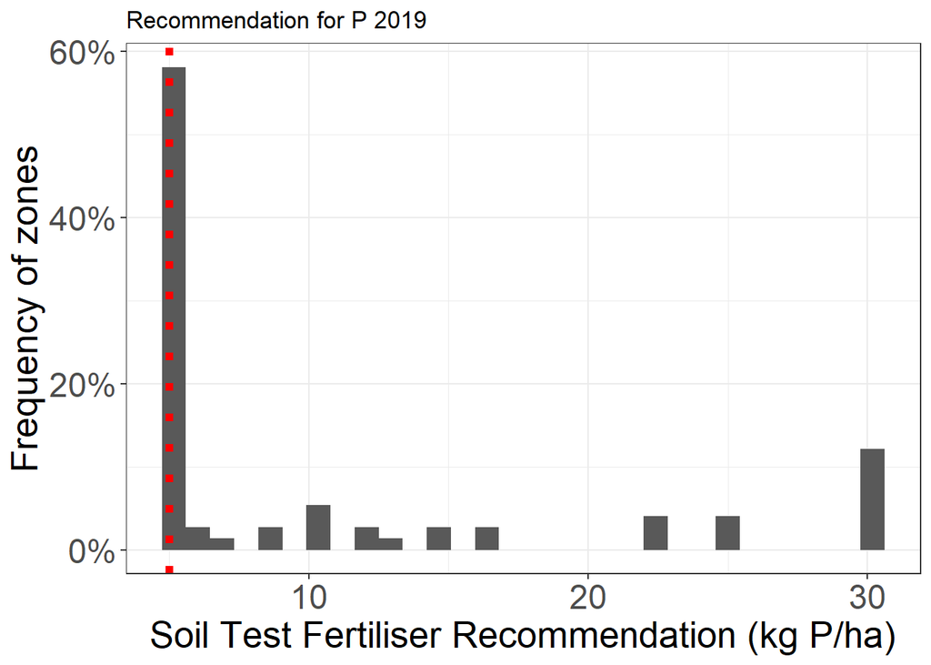

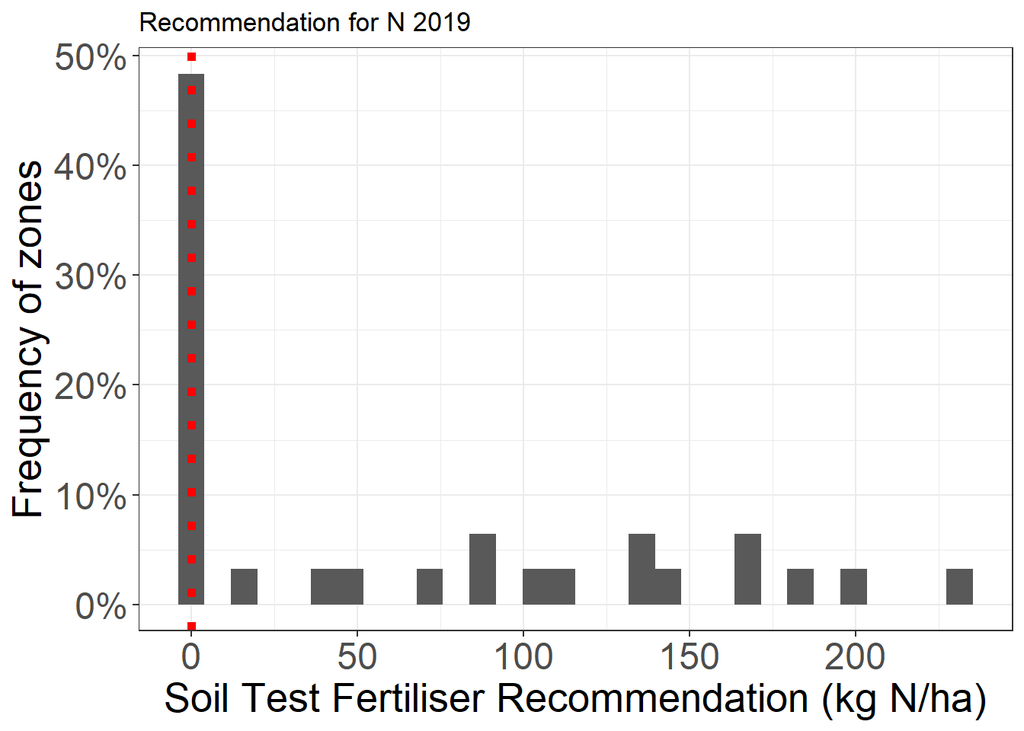

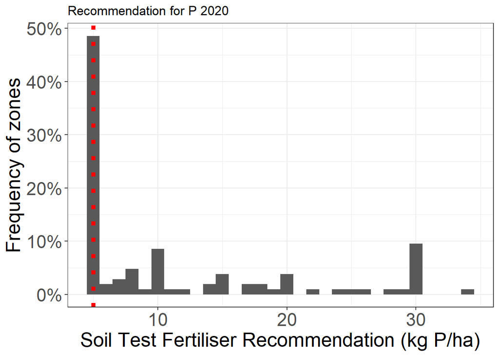

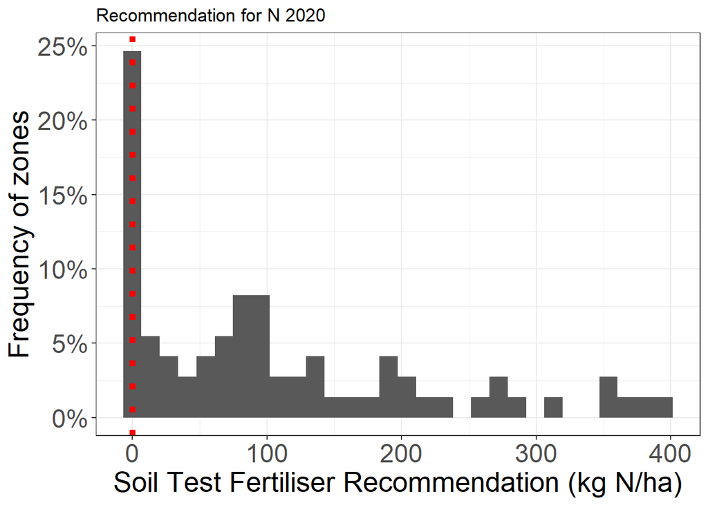

# Count of P zone in 2019

```
## # A tibble: 1 x 1
##   zone_2019_P
##         <int>
## 1          74
```

# Count of P zone in 2019 that had rec rate >= 5

zones with a likley resposne to P fert

```
## # A tibble: 1 x 2
##   yld_repsonse_likely_to_p count_p_over5
## * <chr>                            <int>
## 1 respose                             74
```

# Count of P zone in 2019 rec rate suggested changing planned practice

```
## # A tibble: 3 x 2
##   soil_test_says_P count_vs_GSP
## * <chr>                   <int>
## 1 add_more_P                  4
## 2 less_P                     15
## 3 <NA>                       55
```

# Count of N zone in 2019

```
## # A tibble: 1 x 1
##   zone_2019_N
##         <int>
## 1          31
```

# Count of N zone in 2019 that had rec rate > 0

```
## # A tibble: 2 x 2
##   yld_repsonse_likely_to_n count_n_over0
## * <chr>                            <int>
## 1 no_resposne                         15
## 2 respose                             16
```

# Count of N zone in 2019 rec rate suggested changing planned practice

```
## # A tibble: 2 x 2
##   soil_test_says_N count_vs_GSP
## * <chr>                   <int>
## 1 less_N                      7
## 2 <NA>                       24
```

# Count of P zone in 2020

```
## # A tibble: 1 x 1
##   count
##   <int>
## 1   106
```

# Count of P zone in 2020 that had rec rate > = 5

zones with a likley resposne to P fert

```
## # A tibble: 2 x 2
##   yld_repsonse_likely_to_p count_P_over5
## * <chr>                            <int>
## 1 no_resposne                          1
## 2 respose                            105
```

# Count of P zone in 2020 rec rate suggested changing planned practice

```
## # A tibble: 4 x 2
##   soil_test_says_P count_vs_GSP
## * <chr>                   <int>
## 1 add_more_P                 12
## 2 less_P                     25
## 3 no_change                   1
## 4 <NA>                       68
```

# Count of N zone in 2020

```
## # A tibble: 1 x 1
##   zone_2020_N
##         <int>
## 1          73
```

# Count of N zone in 2020 that had rec rate > 0

```
## # A tibble: 2 x 2
##   yld_repsonse_likely_to_n count_n_over0
## * <chr>                            <int>
## 1 no_resposne                         18
## 2 respose                             55
```

# Count of N zone in 2020 rec rate suggested changing planned practice

```
## # A tibble: 4 x 2
##   soil_test_says_N count_vs_GSP
## * <chr>                   <int>
## 1 add_more_N                 28
## 2 less_N                      6
## 3 no_change                   1
## 4 <NA>                       38
```

## Did the soil test recommendations lead to greater gross margins?

We don’t always have a match with the recom rates and what as applied. So we have calualted the best match based on: how much N / P was applied in the season (or we were told about) what the recommeded rate was calualted from the soil test.

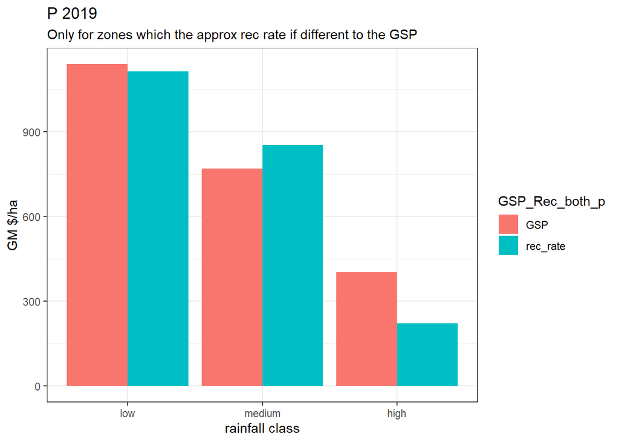

```
## [1] "other"    "GSP"      "rec_rate" "both"
```

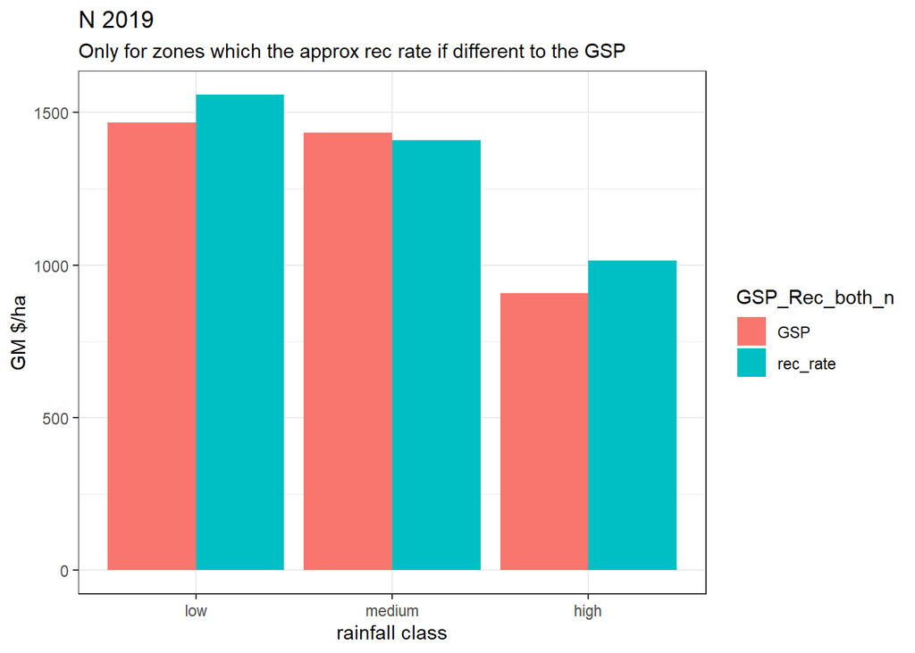

2020

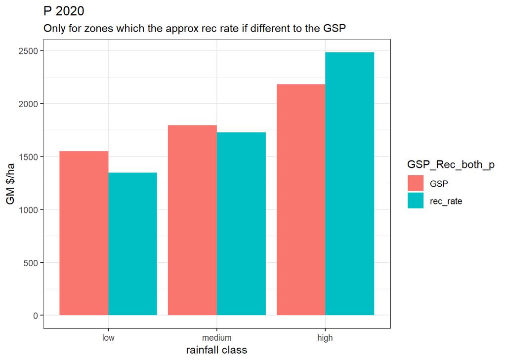

```
## [1] rec_rate other    GSP      both
## Levels: both GSP other rec_rate
```

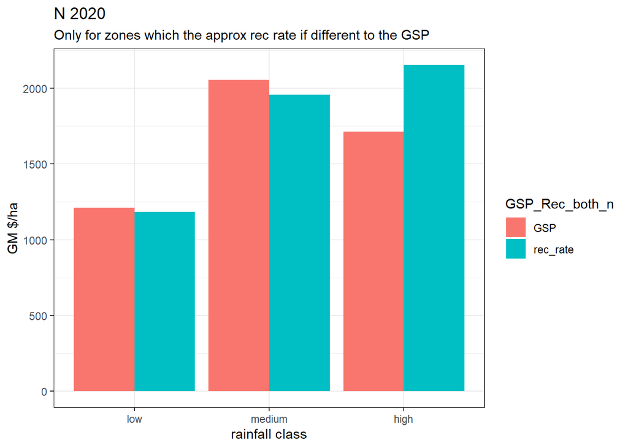